# D213 Advanced Data Analytics Task 1: Time Series Modeling

## Part I: Research Question

### A. Describe the purpose of this data analysis by doing the following:

*1. Summarize one research question that is relevant to a real-world organizational situation captured in the selected data set and that you will answer using time series modeling techniques.*

> - Using the past two years of our hospital revenue data, can we effectively forecast revenue from the hospital data by using Time Series modeling on our data?

*2. Define the objectives or goals of the data analysis. Ensure your objectives or goals are reasonable within the scope of the scenario and are represented in the available data.*

> - The goal of this data analysis is to be able to use Time Series Modeling, ARIMA in this case, to be able to predict future revenue from the hospital. Since we have data that showcases dates and revenue, we want our Time Series Model, ARIMA, to find any patterns and trends and incorporate that into predicting future revenues. This will be beneficial for the hospital system to be able to do further analysis as to why revenue might not be growing during certain time periods, why some time periods it is growing or if revenue is staying stagnant and not benefiting the business. Furthermore, identifying and being able to forecast from our data will can be able to help in the hospitals biggest issue seen from the WGU Data Dictionary which is readmissions.

## Part II: Method Justification

### B. Summarize the assumptions of a time series model including stationarity and autocorrelated data.

> - In this time series model analysis we will be using ARIMA. ARIMA stands for Autoregressive Integrated Moving Average. In order for our model to produce key results, it will rely on a few assumptions.
> - We have the assumption of *stationary*. Our model needs to be stationary. This indicates that our model shows our mean, variance and autocovariance in a constant matter. There are no seasonality or trends. It requires that it remains unchanged over time.
> - We then have *autocorrelated data*. This means that there is a relationship between timeseries and it's lagged values. In other words, this assumes that our past values in our data will influence our future values. This is crucial for making sure our model accurately reflects the patterns and trends in the data for meaningful forecasting.
> - We also have the assumption that the *residuals are independent*. This will note that there are no patterns or trends remaining and if they are the forecasting model won't be as efficient. To add, we also must make sure that we have no outliers in this time series data, as it will skew results and not give us those optimal results we are looking for.

## Part III: Data Preparation

### C. Summarize the data cleaning process by doing the following:

> 1. Provide a line graph visualizing the realization of the time series.

```python
#Import data libraries and packages as needed
import pandas as pd
import numpy as np
import matplotlib.pyplot as plt
import seaborn as sns
from matplotlib import pyplot
from datetime import datetime
import statsmodels.api as sm
from statsmodels.graphics import tsaplots
from statsmodels.tsa.stattools import adfuller
from statsmodels.tsa.seasonal import seasonal_decompose
from pandas.plotting import autocorrelation_plot
from statsmodels.graphics.tsaplots import plot_predict
from statsmodels.graphics.tsaplots import plot_acf
from statsmodels.graphics.tsaplots import plot_pacf
from sklearn.model_selection import train_test_split
from statsmodels.tsa.arima.model import ARIMA
from pmdarima import auto_arima
from math import sqrt
import math
from sklearn.metrics import mean_squared_error
from sklearn.metrics import mean_absolute_error, mean_squared_error
import warnings
warnings.filterwarnings("ignore")
```

```python
#Read our dataset & view it
df = pd.read_csv("medical_time_series .csv")
df.head()
```

|  | Day | Revenue |
| --- | --- | --- |
| 0 | 1 | 0.000000 |
| 1 | 2 | -0.292356 |
| 2 | 3 | -0.327772 |
| 3 | 4 | -0.339987 |
| 4 | 5 | -0.124888 |

```python
#Review data information --
df.info()
```

```
<class 'pandas.core.frame.DataFrame'>
RangeIndex: 731 entries, 0 to 730
Data columns (total 2 columns):
 #   Column   Non-Null Count  Dtype
---  ------   --------------  -----
 0   Day      731 non-null    int64
 1   Revenue  731 non-null    float64
dtypes: float64(1), int64(1)
memory usage: 11.5 KB
```

```python
df.isnull().any()
```

```
Day        False
Revenue    False
dtype: bool
```

```python
#Dictionary has no indication of start date -- will begin 2020 calling pandas to_datetime
start_date = pd.to_datetime('2020-01-01')
df['Date'] = pd.to_timedelta(df['Day'] - 1, unit='D') + start_date
df = pd.DataFrame(df)
df
```

|  | Day | Revenue | Date |
| --- | --- | --- | --- |
| 0 | 1 | 0.000000 | 2020-01-01 |
| 1 | 2 | -0.292356 | 2020-01-02 |
| 2 | 3 | -0.327772 | 2020-01-03 |
| 3 | 4 | -0.339987 | 2020-01-04 |
| 4 | 5 | -0.124888 | 2020-01-05 |
| ... | ... | ... | ... |
| 726 | 727 | 15.722056 | 2021-12-27 |
| 727 | 728 | 15.865822 | 2021-12-28 |
| 728 | 729 | 15.708988 | 2021-12-29 |
| 729 | 730 | 15.822867 | 2021-12-30 |
| 730 | 731 | 16.069429 | 2021-12-31 |

731 rows × 3 columns

```python
#let's drop the original Day column for better analysis and review
df = df.drop(columns='Day')
df.head()
```

|  | Revenue | Date |
| --- | --- | --- |
| 0 | 0.000000 | 2020-01-01 |
| 1 | -0.292356 | 2020-01-02 |
| 2 | -0.327772 | 2020-01-03 |
| 3 | -0.339987 | 2020-01-04 |
| 4 | -0.124888 | 2020-01-05 |

```python
#Replace our index with Date
df.set_index('Date',inplace=True)
```

```python
df.head()
```

| Date | Revenue |
| --- | --- |
| 2020-01-01 | 0.000000 |
| 2020-01-02 | -0.292356 |
| 2020-01-03 | -0.327772 |
| 2020-01-04 | -0.339987 |
| 2020-01-05 | -0.124888 |

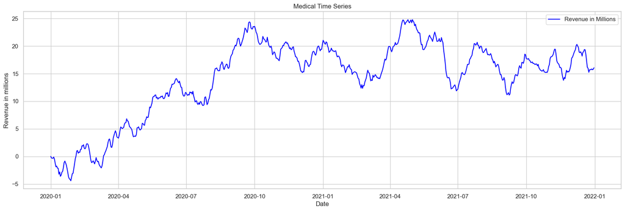

```python
#Provide a line graph visualizing the realization of the time series
sns.set(style="whitegrid")
plt.figure(figsize=(20, 6))
sns.lineplot(data=df, x='Date', y='Revenue', label='Revenue in Millions', color='blue')
plt.xlabel('Date')
plt.ylabel('Revenue in millions')
plt.title('Medical Time Series')
plt.show()
```

```python
df.info()
```

```
<class 'pandas.core.frame.DataFrame'>
DatetimeIndex: 731 entries, 2020-01-01 to 2021-12-31
Data columns (total 1 columns):
 #   Column   Non-Null Count  Dtype
---  ------   --------------  -----
 0   Revenue  731 non-null    float64
dtypes: float64(1)
memory usage: 11.4 KB
```

```python
#split to train/test -> split own 80/20
df_train = df.iloc[:584]
df_test = df.iloc[584:]
```

```python
df_train
```

| Date | Revenue |
| --- | --- |
| 2020-01-01 | 0.000000 |
| 2020-01-02 | -0.292356 |
| 2020-01-03 | -0.327772 |
| 2020-01-04 | -0.339987 |
| 2020-01-05 | -0.124888 |
| ... | ... |
| 2021-08-02 | 19.782635 |
| 2021-08-03 | 19.088265 |
| 2021-08-04 | 18.805501 |
| 2021-08-05 | 18.910233 |
| 2021-08-06 | 19.186089 |

584 rows × 1 columns

```python
df_test
```

| Date | Revenue |
| --- | --- |
| 2021-08-07 | 19.312734 |
| 2021-08-08 | 19.576725 |
| 2021-08-09 | 18.988035 |
| 2021-08-10 | 18.437608 |
| 2021-08-11 | 18.519085 |
| ... | ... |
| 2021-12-27 | 15.722056 |
| 2021-12-28 | 15.865822 |
| 2021-12-29 | 15.708988 |
| 2021-12-30 | 15.822867 |
| 2021-12-31 | 16.069429 |

147 rows × 1 columns

## C2 - Describe the time step formatting of the realization, including any gaps in measurement and the length of the sequence.

> We did not have any gaps in measurement as seen on the graphs above. When reviewing our data we have 731 rows which is 731 days. This is 2 years and each day correlates to it's row and day. There are no gaps of days or any absent data. Since our data dictionary did not indicate a certain time series, the analysis went with year 2020. The reason for this being is because 731 rows / 2 - split into two years. It is not evenly. One will have 365 and other will have 366. 2020 was a leap year and the rest indicates 2021. From this, we decide to work in days starting January 1 as a normal calendar year. Since we do not have further information for fiscal year, it will be assumed it starts on January 1. We also note that we have 2 columns, one for date and the other for revenue. Date will be our index. Revenue is in millions. This is the type of data we will be working with. It is what time series models take, a time series object. As seen above we showcase how we converted to dates and split to two years. We see 2020-01-01 to 2021-12-31. This is the time range we will be working with.

## C3 - Evaluate the stationarity of the time series

> Below we evaluate for stationarity. We use Augmented Dickey-Fuller test for find those values and indicate whether our data is stationary or not(any trends?). We notice that it is not by noticing an upwards trend in our graphs, plus we calculate those values with tests. Recall that this is a crucial assumption in time series modeling. By ensuring we have stationarity we are building a more reliable and valid model.

```python
#Test for Stationary with adfuller (Augmented Dickey-Fuller (ADF) test)
result = adfuller(df['Revenue'])
print('ADF Statistic:', result[0])
print('p-value:', result[1])
print('#Lags Used:', result[2])
print('Number of Observations:', result[3])
print('Critical Values:', result[4])
```

```
ADF Statistic: -2.2183190476089454
p-value: 0.19966400615064356
#Lags Used: 1
Number of Observations: 729
Critical Values: {'1%': -3.4393520240470554, '5%': -2.8655128165959236, '10%': -2.5688855736949163}
```

```python
if result[1] <= 0.05:
    print("Reject the null hypothesis. Data is stationary")
else:
    print("Accept null hypothesis. Data is non-stationary ")
```

```
Accept null hypothesis. Data is non-stationary
```

```python
critical_values = result[4]
ADF = result[0]
for key, value in critical_values.items():
    if ADF < value:
        print('Data is stationary')
    else:
        print('Data is non-stationary')
```

```
Data is non-stationary
Data is non-stationary
Data is non-stationary
```

```python
#Turn into stationary for time series purposes using differencing
stationary_data = df.diff().dropna()
```

```python
result2 = adfuller(stationary_data['Revenue'])
print('ADF Statistic:', result2[0])
print('p-value:', result2[1])
print('#Lags Used:', result2[2])
print('Number of Observations:', result2[3])
print('Critical Values:', result2[4])
```

```
ADF Statistic: -17.374772303557062
p-value: 5.113206978840171e-30
#Lags Used: 0
Number of Observations: 729
Critical Values: {'1%': -3.4393520240470554, '5%': -2.8655128165959236, '10%': -2.5688855736949163}
```

```python
if result2[1] <= 0.05:
    print("Reject the null hypothesis. Data is stationary")
else:
    print("Accept null hypothesis. Data is non-stationary ")
```

```
Reject the null hypothesis. Data is stationary
```

```python
critical_values = result2[4]
ADF = result2[0]
for key, value in critical_values.items():
    if ADF < value:
        print('Data is stationary')
    else:
        print('Data is non-stationary')
```

```
Data is stationary
Data is stationary
Data is stationary
```

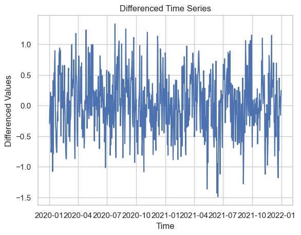

```python
#Provide a line graph visualizing the realization of the time series
#Recall that what we did before was use diff() which is the difference between each consecutive pair of observations in our data
#it is the change in value from one point to the next point, this shows our data is stationary.
plt.plot(stationary_data)
plt.title('Differenced Time Series')
plt.xlabel('Time')
plt.ylabel('Differenced Values')
plt.show()
```

```python
stationary_data
```

| Date | Revenue |
| --- | --- |
| 2020-01-02 | -0.292356 |
| 2020-01-03 | -0.035416 |
| 2020-01-04 | -0.012215 |
| 2020-01-05 | 0.215100 |
| 2020-01-06 | -0.366702 |
| ... | ... |
| 2021-12-27 | -0.032693 |
| 2021-12-28 | 0.143766 |
| 2021-12-29 | -0.156834 |
| 2021-12-30 | 0.113880 |
| 2021-12-31 | 0.246562 |

730 rows × 1 columns

## C5 Provide a copy of the cleaned data set.

> Copy of cleanded data set provided as files in task submission.

```python
stationary_data.to_csv('stationary_data.csv')
```

```python
df_train.to_csv('trainD213.csv')
```

```python
df_test.to_csv('testD213.csv')
```

## Part IV: Model Identification and Analysis

*D. Analyze the time series data set by doing the following:*

> 1. Report the annotated findings with visualizations of your data analysis, including the following elements:

## The presence or lack of a seasonal component

> Below we review any seasonality. We decompose the data and further analyze if a pattern is present. We call for seasonal_decompose on our Revenue values from our stationary_data. We use additive because seasonal variation is relatively constant over time. The period of 1 has been chosen since we have data spanning yearly. We note this in the graphs above and because our data is stationary as we have converted and proved. In the graph given to us by seasonal component below, we see that there are no patterns or trends present. To further prove this, we run auto_arima that can give us our p,q,d values for our ARIMA model AND it will detect if we have seasonality. The set of paranthesis (0,0,0) let's us know that we have no seasonality. We have also aquired the best p,q,d for our model in which we will be using further along our analysis (Dr. Sewell 2024).

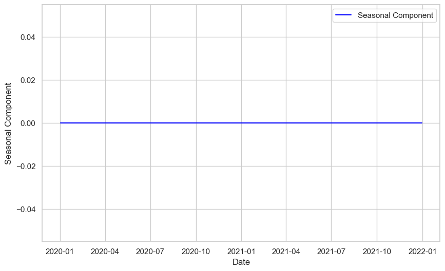

```python
#call for seasonal decomposition and plot to review results - using t (as powerpoints we have two years only and looking at yearly so our period is 1)
decomposition = seasonal_decompose(stationary_data['Revenue'], model='additive', period=1)
plt.figure(figsize=(10, 6))
plt.plot(decomposition.seasonal, label='Seasonal Component', color='blue')
plt.xlabel('Date')
plt.ylabel('Seasonal Component')
plt.legend()
plt.grid(True)
plt.show()
```

```python
#Another way of reassuring seasonality is correct -- we see set of (0,0,0) indicating no seasonality
stepwise_fit = auto_arima(stationary_data['Revenue'], trace = True, supress_warning=True)
stepwise_fit.arima_res_.aic
```

```
Performing stepwise search to minimize aic
 ARIMA(2,0,2)(0,0,0)[0] intercept   : AIC=883.277, Time=0.38 sec
 ARIMA(0,0,0)(0,0,0)[0] intercept   : AIC=1015.972, Time=0.05 sec
 ARIMA(1,0,0)(0,0,0)[0] intercept   : AIC=881.359, Time=0.05 sec
 ARIMA(0,0,1)(0,0,0)[0] intercept   : AIC=906.199, Time=0.07 sec
 ARIMA(0,0,0)(0,0,0)[0]             : AIC=1015.481, Time=0.04 sec
 ARIMA(2,0,0)(0,0,0)[0] intercept   : AIC=883.300, Time=0.07 sec
 ARIMA(1,0,1)(0,0,0)[0] intercept   : AIC=883.314, Time=0.09 sec
 ARIMA(2,0,1)(0,0,0)[0] intercept   : AIC=883.348, Time=0.29 sec
 ARIMA(1,0,0)(0,0,0)[0]             : AIC=879.982, Time=0.07 sec
 ARIMA(2,0,0)(0,0,0)[0]             : AIC=881.911, Time=0.06 sec
 ARIMA(1,0,1)(0,0,0)[0]             : AIC=881.927, Time=0.05 sec
 ARIMA(0,0,1)(0,0,0)[0]             : AIC=905.166, Time=0.03 sec
 ARIMA(2,0,1)(0,0,0)[0]             : AIC=881.947, Time=0.11 sec

Best model:  ARIMA(1,0,0)(0,0,0)[0]
Total fit time: 1.382 seconds
```

```
879.9818304960618
```

## Trends

> Below is a graph of trends. We notice there are no apparent trends.

```
<function matplotlib.pyplot.show(close=None, block=None)>
```

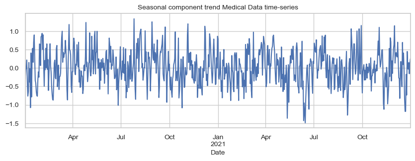

```python
trend = decomposition.trend
ax = trend.plot(figsize=(10,3), fontsize = 10)
ax.set_xlabel('Date', fontsize=10)
ax.set_title('Seasonal component trend Medical Data time-series', fontsize=10)
plt.show
```

## The autocorrelation function

> Below is the autocorrelation and partial autocorrelation. Here, we can determine the most approrpiate order to forecast our medical revenue. We note that after before 2 lags in our ACF we have a strong correlation, but in PACF we notice our that after lag 1 we have a cut off. Thus, this leads us to have an AR model of (p), p indicating where that cut off was at, which is 1 (Brownlee 2020). This AR(1) model will go as follows (FOR NOW, until we further evaluate more numbers) - (1,1,0). p: is our lags we indicated from our plots below d: is our differencing which we used previously q: is moving average component This is relevant as our ARIMA model takes 3 different values and we must choose the best ones for our model. This also confirms when we did auto_arima and gave us the exact same numbers for our best model. We see this in our training /original set too for validation.

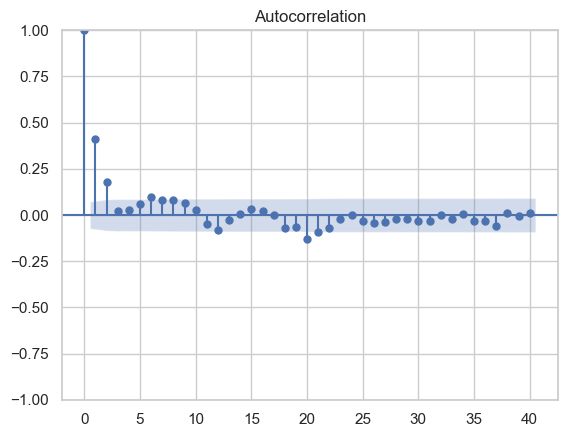

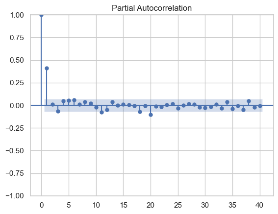

```python
#Autocorrelation function for use in model (using differenced data)
act_diff = plot_acf(stationary_data['Revenue'], lags=40)
pact_diff = plot_pacf(stationary_data['Revenue'], lags=40)
plt.show()
```

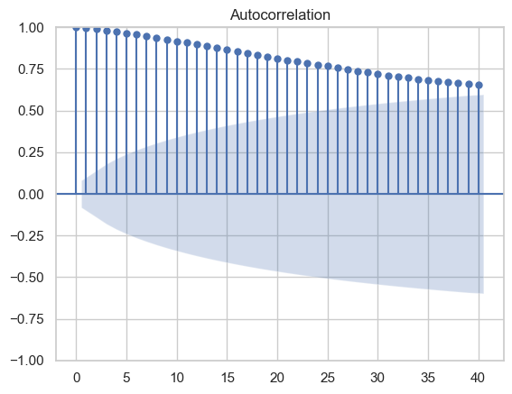

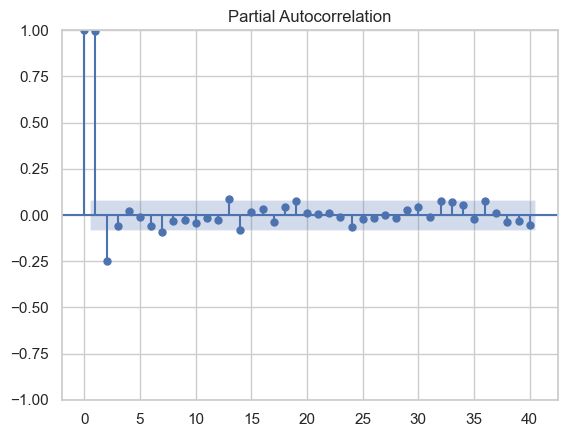

```python
act_diff = plot_acf(df_train['Revenue'], lags=40)
pact_diff = plot_pacf(df_train['Revenue'], lags=40)
plt.show()
```

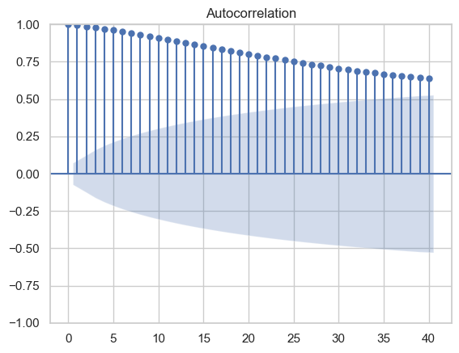

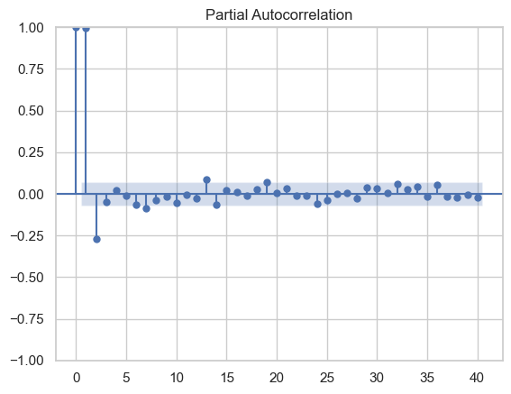

```python
act_diff = plot_acf(df['Revenue'], lags=40)
pact_diff = plot_pacf(df['Revenue'], lags=40)
plt.show()
```

## The Spectral Density

> Below we review spectral density on our revenue values. This is another way to detrend data and observe seasonality. We see that there is no seasonality in our data.

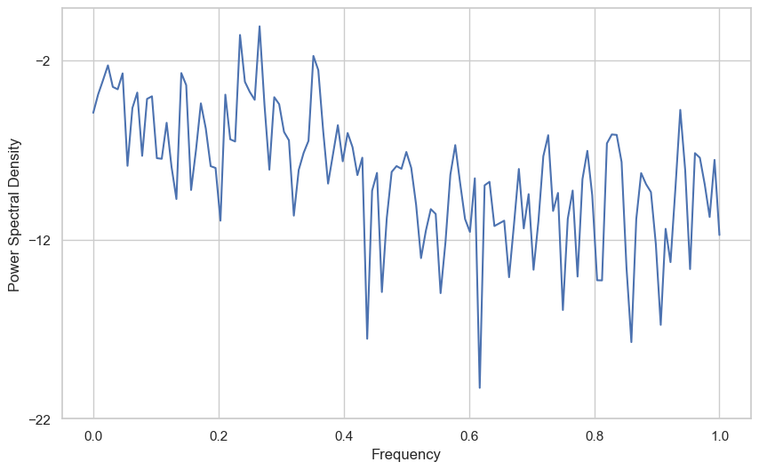

```python
#call for plt.psd for spectral density and review for seasonality
plt.figure(figsize=(10, 6))
plt.psd(stationary_data.Revenue)
plt.xlabel('Frequency')
plt.ylabel('Power Spectral Density')
plt.show()
```

# The Decomposed Time Series

> Below is the decomposed time series. This is an additive value, meaning it is relatively constant over time as seen previously. By decomposing our time series into its trend, seasonal and residual components we are able to further analyze any underlying patters present in the data. This will also be very helpful in forecasting.

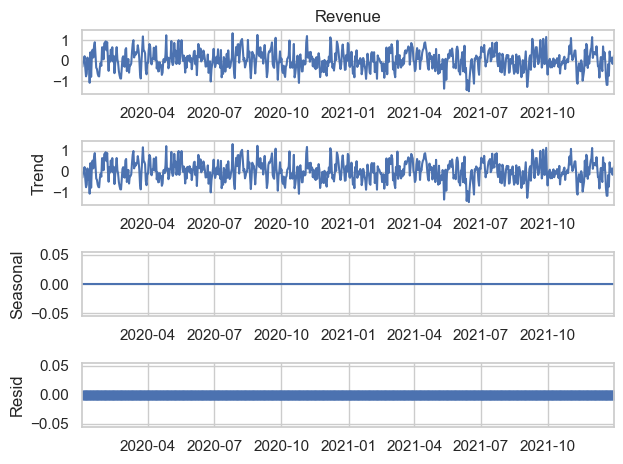

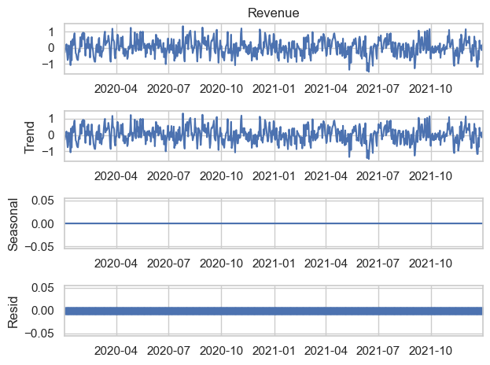

```python
#Review decomposed time series
decomposition.plot()
```

# Confirmation of the lack of trends in the residuals of the decomposed series

> We must confirm there is no trends in the residuals to assess the goodness of fi of our decomposition model and retrieve any remaining patterns or anomalies that may lead us to believe we should do further cleaning. We see no trends below.

```
<function matplotlib.pyplot.show(close=None, block=None)>
```

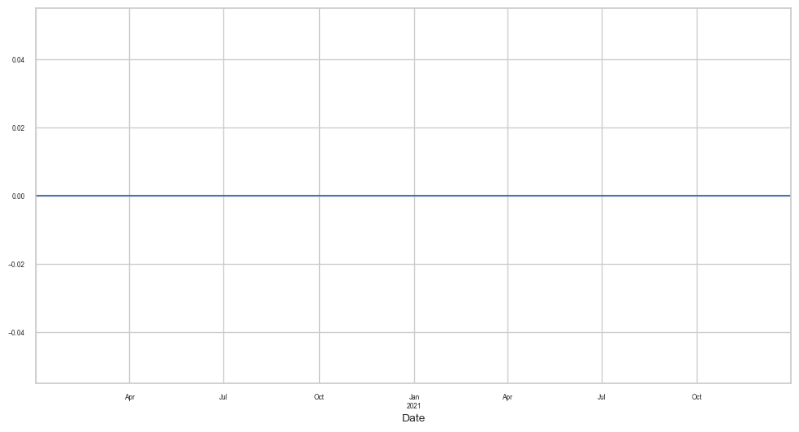

```python
#confirmation of the lack of trends in the residuals of the decomposed series
resid = decomposition.resid
ax = resid.plot(figsize=(12,6), fontsize = 6)
ax.set_xlabel('Date', fontsize=10)
plt.show
```

## D2. Identify an autoregressive integrated moving average (ARIMA) model that accounts for the observed trend and seasonality of the time series data.

> After doing our previous analysis, we see that we have no seasonality, therefore we use ARIMA model. Furthermore, from doing auto_arima and inspecting trends, autocorrelation functions, spectral density, lack of residuals trend and the decomposed time series we have finalized an order to input into our model. This will give us the most optimal results (Pathak 2024). Recall that we split our data into training/test, so we will be using our training set for this. The model below accounts for the observed trend and seasonality of the time series data using our training first.

```python
#Above we used different variations to find for p,d,q values and reassure seasonality and stationary
#Below we will use autorima do indicate best values for our model as seen in D213 webinar 2
stepwise_fit = auto_arima(df['Revenue'], trace = True, supress_warning=True)
stepwise_fit.arima_res_.aic
```

```
Performing stepwise search to minimize aic
 ARIMA(2,1,2)(0,0,0)[0] intercept   : AIC=883.277, Time=0.21 sec
 ARIMA(0,1,0)(0,0,0)[0] intercept   : AIC=1015.972, Time=0.04 sec
 ARIMA(1,1,0)(0,0,0)[0] intercept   : AIC=881.359, Time=0.05 sec
 ARIMA(0,1,1)(0,0,0)[0] intercept   : AIC=906.199, Time=0.05 sec
 ARIMA(0,1,0)(0,0,0)[0]             : AIC=1015.481, Time=0.02 sec
 ARIMA(2,1,0)(0,0,0)[0] intercept   : AIC=883.300, Time=0.06 sec
 ARIMA(1,1,1)(0,0,0)[0] intercept   : AIC=883.314, Time=0.09 sec
 ARIMA(2,1,1)(0,0,0)[0] intercept   : AIC=883.348, Time=0.20 sec
 ARIMA(1,1,0)(0,0,0)[0]             : AIC=879.982, Time=0.03 sec
 ARIMA(2,1,0)(0,0,0)[0]             : AIC=881.911, Time=0.04 sec
 ARIMA(1,1,1)(0,0,0)[0]             : AIC=881.927, Time=0.06 sec
 ARIMA(0,1,1)(0,0,0)[0]             : AIC=905.166, Time=0.03 sec
 ARIMA(2,1,1)(0,0,0)[0]             : AIC=881.947, Time=0.11 sec

Best model:  ARIMA(1,1,0)(0,0,0)[0]
Total fit time: 1.003 seconds
```

```
879.9818304707662
```

```python
#Build ARIMA model - frequency D will be used by pandas (correct, using days)
#ODER MEANING: (1,0,0) - 1: order of the autoregressive component, set to 1. - we are using the previous lag1 to predict current model
#0: degree of differencing set to 1 since stationary data we used 1
#0: order of moving average component - no moving average included in model
#ARIMA model will apply the difference for us - so use original data not stationary
#We now apply the same values as seen above
model = ARIMA(df_train['Revenue'], order=(1,1,0),freq='D')
model_fit = model.fit()
model_fit.summary()
```

SARIMAX Results

| Dep. Variable: | Revenue | No. Observations: | 584 |
| --- | --- | --- | --- |
| Model: | ARIMA(1, 1, 0) | Log Likelihood | -350.812 |
| Date: | Thu, 08 Feb 2024 | AIC | 705.625 |
| Time: | 19:28:14 | BIC | 714.361 |
| Sample: | 01-01-2020 | HQIC | 709.030 |
|  | - 08-06-2021 |  |  |
| Covariance Type: | opg |  |  |

|  | coef | std err | z | P>\|z\| | [0.025 | 0.975] |
| --- | --- | --- | --- | --- | --- | --- |
| ar.L1 | 0.4106 | 0.038 | 10.837 | 0.000 | 0.336 | 0.485 |
| sigma2 | 0.1950 | 0.012 | 15.888 | 0.000 | 0.171 | 0.219 |

| Ljung-Box (L1) (Q): | 0.15 | Jarque-Bera (JB): | 1.86 |
| --- | --- | --- | --- |
| Prob(Q): | 0.70 | Prob(JB): | 0.39 |
| Heteroskedasticity (H): | 1.04 | Skew: | -0.05 |
| Prob(H) (two-sided): | 0.78 | Kurtosis: | 2.74 |

Warnings:  
[1] Covariance matrix calculated using the outer product of gradients (complex-step).

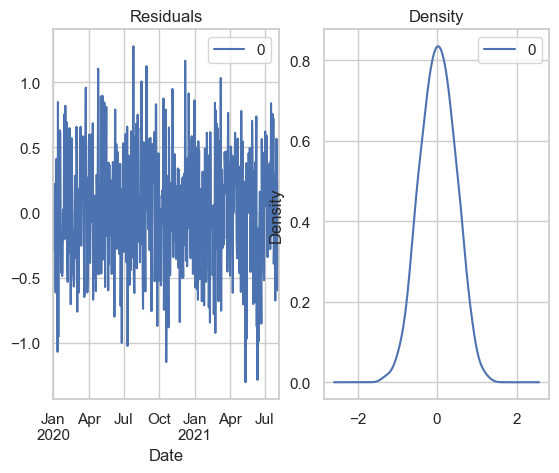

```python
#double check model is as expected -- n
residuals = pd.DataFrame(model_fit.resid)
fig, ax = plt.subplots(1,2)
residuals.plot(title="Residuals", ax=ax[0])
residuals.plot(kind='kde', title='Density', ax=ax[1])
plt.show()
```

## D3. Perform a forecast using the derived ARIMA model identified in part D2.

> Now that we have run our model, we can run a forecast and make predictions. Below is our code using the above ARIMA model that we computed from our calculations.

```python
start = len(df_train)
end = len(df_train) + len(df_test) - 1
predictions = model_fit.predict(start, end, typ = 'levels')
print(predictions)
```

```
2021-08-07    19.299360
2021-08-08    19.345870
2021-08-09    19.364967
2021-08-10    19.372809
2021-08-11    19.376029
                ...
2021-12-27    19.378272
2021-12-28    19.378272
2021-12-29    19.378272
2021-12-30    19.378272
2021-12-31    19.378272
Freq: D, Name: predicted_mean, Length: 147, dtype: float64
```

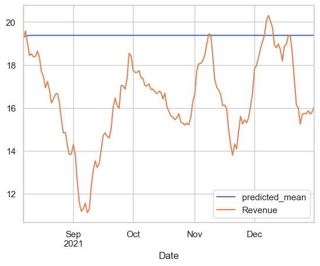

```python
predictions.plot(legend = True)
df_test['Revenue'].plot(legend = True)
```

## D4. Provide the output and calculations of the analysis you performed.

> Code provided throughout notebook

## D5. Provide the code used to support the implementation of the time series model.

> Code provided throughout notebook

# Part V: Data Summary and Implications

## E. Summarize your findings and assumptions by doing the following:

### The selection of an ARIMA model

> The reason that an ARIMA model was selected was because the goal of our analysis was to predict future revenue values from our temporal hospital revenue data. ARIMA model has the ability to capture trends, seasonal patterns or any other underlying patterns in our revenue data. The reason why this was selected is because the ARIMA model is able to provide us with meaninful insights into our revenue over time. To add, ARIMA models are known to be robust to outliers and missing data(Pathak 2024). This means that if the hospital had revenue missing for example any insurance biling or unexpected events then our ARIMA model will ensure that it can still provide reliable forecasts despite those data discrepancies. To add we chose AR(1) model because the auto_arima indicated this was the best fit for our model. It also showed the second set of (0,0,0) as having no seasonality in our data set. When we ran ACF and PACF the graphs also indicated that this Autoregressive process with 1 lags because that one current value in our data set is based on the immediately preceding value.

### The prediction interval of the forecast

> The prediction interval of the forecast was based upon how we split our training and test sets. We decided that we would be using 80/20 split. Thus, since we used our training for our ARIMA model we will then be using our test to predict those values. The interval of 20% is 147 since we have a total of 731 observations and training used 584. With this we notice that this interval is on a forecast of 1 day. Therefore, our ARIMA model will work with any patterns or trends to predict revenue in a daily interval.

### A justification of the forecast length

> We were only given two years of data and we split our training/test into 80/20. Training set was 584 values. The rest was 147 which is a little less than half a year. A longer forecast would have required us to have even more years ahead of us to get meaningful results. This is not doable. While our data availablity is only two years (Or 731 days), it is justifiable that we use a forecast length that is not longer than our data set. Since we are working with our training/test we indicate what our length the same as our test set as seen above. To add, we are also returning back to our goal which is to effectively predict revenue and review any patterns or trends throughout our time series data. The length of 147 will give us that type of meaningful results(Dr. William Sewell 2024).

### The model evaluation procedure and error metric

```python
#Validate our ARIMA model of testing
mae = mean_absolute_error(df_test['Revenue'],predictions)
mse = mean_squared_error(df_test['Revenue'],predictions)
rmse = np.sqrt(mse)
print('Mean Absolute Error (MAE):', mae)
print('Mean Squared Error (MSE):', mse)
print('Root Mean Squared Error (RMSE):', rmse)
```

```
Mean Absolute Error (MAE): 2.9836709815516858
Mean Squared Error (MSE): 12.679409586479247
Root Mean Squared Error (RMSE): 3.5608158596702593
```

## E2. Provide an annotated visualization of the forecast of the final model compared to the test set.

```python
final_model = ARIMA(df['Revenue'], order=(1,1,0), freq='D')
final_model = final_model.fit()
final_model.summary()
```

SARIMAX Results

| Dep. Variable: | Revenue | No. Observations: | 731 |
| --- | --- | --- | --- |
| Model: | ARIMA(1, 1, 0) | Log Likelihood | -437.991 |
| Date: | Thu, 08 Feb 2024 | AIC | 879.982 |
| Time: | 19:28:15 | BIC | 889.168 |
| Sample: | 01-01-2020 | HQIC | 883.526 |
|  | - 12-31-2021 |  |  |
| Covariance Type: | opg |  |  |

|  | coef | std err | z | P>\|z\| | [0.025 | 0.975] |
| --- | --- | --- | --- | --- | --- | --- |
| ar.L1 | 0.4142 | 0.034 | 12.258 | 0.000 | 0.348 | 0.480 |
| sigma2 | 0.1943 | 0.011 | 17.842 | 0.000 | 0.173 | 0.216 |

| Ljung-Box (L1) (Q): | 0.02 | Jarque-Bera (JB): | 1.92 |
| --- | --- | --- | --- |
| Prob(Q): | 0.90 | Prob(JB): | 0.38 |
| Heteroskedasticity (H): | 1.00 | Skew: | -0.02 |
| Prob(H) (two-sided): | 0.97 | Kurtosis: | 2.75 |

Warnings:  
[1] Covariance matrix calculated using the outer product of gradients (complex-step).

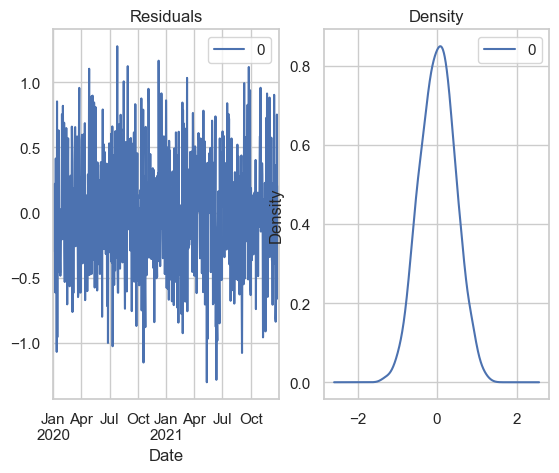

```python
#double check model is as expected -- n
residuals = pd.DataFrame(final_model.resid)
fig, ax = plt.subplots(1,2)
residuals.plot(title="Residuals", ax=ax[0])
residuals.plot(kind='kde', title='Density', ax=ax[1])
plt.show()
```

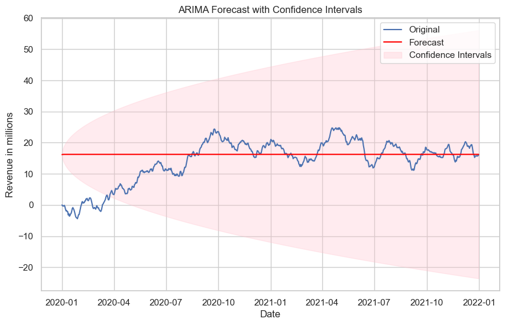

```python
forecast = final_model.get_forecast(steps=len(df))
forecast_mean = forecast.predicted_mean
forecast_conf_int = forecast.conf_int()
plt.figure(figsize=(10, 6))
plt.plot(df.index, df['Revenue'], label='Original')
plt.plot(df.index, forecast_mean, color='red', label='Forecast')
plt.fill_between(df.index, forecast_conf_int.iloc[:, 0], forecast_conf_int.iloc[:, 1], color='pink', alpha=0.3, label='Confidence Intervals')
plt.xlabel('Date')
plt.ylabel('Revenue in millions')
plt.title('ARIMA Forecast with Confidence Intervals')
plt.legend()
plt.show()
```

```python
forecast_mean
```

```
2022-01-01    16.171559
2022-01-02    16.213862
2022-01-03    16.231384
2022-01-04    16.238642
2022-01-05    16.241649
                ...
2023-12-28    16.243774
2023-12-29    16.243774
2023-12-30    16.243774
2023-12-31    16.243774
2024-01-01    16.243774
Freq: D, Name: predicted_mean, Length: 731, dtype: float64
```

```python
df_test['Revenue'].mean()
```

```
16.434480783537417
```

```python
#Validate our ARIMA model
mae = mean_absolute_error(df['Revenue'],forecast_mean)
mse = mean_squared_error(df['Revenue'],forecast_mean)
rmse = np.sqrt(mse)

print('Mean Absolute Error (MAE):', mae)
print('Mean Squared Error (MSE):', mse)
print('Root Mean Squared Error (RMSE):', rmse)
```

```
Mean Absolute Error (MAE): 5.207506332713127
Mean Squared Error (MSE): 52.6292728310318
Root Mean Squared Error (RMSE): 7.254603561259002
```

## E3. Recommend a course of action based on your results.

# Part VI: Reporting

## F. With the information from part E, create your report using an industry-relevant interactive development environment (e.g., an R Markdown document, a Jupyter Notebook). Include a PDF or HTML document of your executed notebook presentation.

> Indicated in this document

## G. Cite the web sources you used to acquire third-party code to support the application.

> (WGU DR. William Sewell) (February 5, 2024). D213 WARIMA II Webinar. WGU Panopto. https://wgu.hosted.panopto.com/Panopto/Pages/Viewer.aspx?id=37007075-c29e-43f2-a106-af7800d45914

> (WGU DR. William Sewell) (February 5, 2024). D213 WARIMA I Webinar. WGU Panopto. https://wgu.hosted.panopto.com/Panopto/Pages/Viewer.aspx?id=358071e7-9c01-4274-a044-af7400ec1c40

## H. Acknowledge sources, using in-text citations and references, for content that is quoted, paraphrased, or summarize

> Brownlee, J. (2020, August 14). A gentle introduction to autocorrelation and partial autocorrelation. MachineLearningMastery.com. https://machinelearningmastery.com/gentle-introduction-autocorrelation-partial-autocorrelation/ Pathak, P. (2024, January 18). Building an Arima model for time series forecasting in python. Analytics Vidhya. https://www.analyticsvidhya.com/blog/2020/10/how-to-create-an-arima-model-for-time-series-forecasting-in-python/ Awan, Abid Ali (2023, August 9)> Time Series Analysis: Arima Models in python. KDnuggets. https://www.kdnuggets.com/2023/08/times-series-analysis-arima-models-python.html Jain, A. P. (2023b, August 22). Time Series Forecasting: Data, analysis, and Practice. neptune.ai. https://neptune.ai/blog/time-series-forecasting Brownlee, J. (2023, November 15). 11 classical time series forecasting methods in python (cheat sheet). MachineLearningMastery.com. https://machinelearningmastery.com/time-series-forecasting-methods-in-python-cheat-sheet/